# Appendix E: Fitting the Lester biphasic growth model without maturity data using a Bayesian MCMC approach

Kyle Wilson$^1$ and Andrew Honsey$^2$ $^1$The University of Calgary $^2$University of Minnesota

October 5, 2017

This appendix is in support of Wilson *et al.* (2017). The citation style language (csl) used herein is the methods-in-ecology-and-evolution.csl file which can be downloaded from https://github.com/citation-style-language/styles/blob/master/methods-in-ecology-and-evolution.csl and placed in the same directory as this .rmd file.

The following code is an example application of the Lester biphasic growth model (Lester, Shuter & Abrams 2004) to length-at-age data in the absence of any information on maturity (e.g., maturity data, *a priori* estimates of age-at-maturity, etc.). In this case, the age-at-maturity parameter $T$ is estimated simultaneously with the other model parameters using Bayesian MCMC via JAGS. First, we load the required libraries. Note that these packages, along with the JAGS program (http://mcmc-jags.sourceforge.net/), must be installed for the code to run.

```r
library(runjags)
library(rjags)
library(stats4)
library(coda)
```

Next, we define a few functions that will be used later.

```r
Corner_text <- function(text, location="topright") #function to write text to the corner of plots
{
  legend(location,legend=text, bty ="n", pch=NA)
}

get_beta <- function(mean,cv) #function that returns the alpha and beta shape parameters of a beta distribution, based on the mean and variation of a given beta distribution
{
  sd <- mean*cv
  alpha <- -((mean*(mean^2+sd^2-mean))/sd^2)
  beta <- alpha/mean-alpha
  return(list(alpha=alpha,beta=beta))
}

panel.cor <- function(x, y, digits = 2, prefix = "", cex.cor, ...)
{
  usr <- par("usr"); on.exit(par(usr))
  par(usr = c(0, 1, 0, 1))
  r <- abs(cor(x, y))
  txt <- format(c(r, 0.123456789), digits = digits)[1]
  txt <- paste0(prefix, txt)
  if(missing(cex.cor)) cex.cor <- 0.8/strwidth(txt)
  text(0.5, 0.5, txt, cex = cex.cor * r)
}

rngList <- function(x,y){ #this function creates randomly 'jittered' starting values for each MCMC chain
  lis <- lapply(x, lapply, length) #get the lower order dimensions of the list x
  names(lis) <- lapply(x, length) #get the names of those dimensions of the list x
  l_el <- length(names(lis)) #get the maximum number elements of the highest order dimensions of the list x
  for(i in 1:(l_el-2)) #loop through those dimensions which need to be 'jittered'
  {
    x[[i]] <- x[[i]]*(1+runif(1,-0.15,0.15)) #jitter values of the list by +/- 15%
  }
  x[[l_el]] <- round(runif(1,1,100000),0) #have a random RNG seed for the MCMC chain
  return(x)
}
```

### Data generation

We simulate length-at-age data for a single population for the Lester growth model (Lester, Shuter & Abrams (2004)). The age range of the fishes is read in as a vector of integers. True somatic growth rate can be any positive number and represents the length (in mm) accumulated per year in the late-stage juvenile phase. The variable $t_1$ represents the hypothetical age at length 0 (i.e., the *x*-intercept for the juvenile phase). We use a reasonable value for the coefficient of variation in length-at-age ($cv$) of 15%, a typical observation among most fishes (see review in Lorenzen (2016)). The variable $T$ (or Tmat in the R code below) represents the age-at-maturity for the population. The parameter $g$ represents the proportion of energy in the adult phase allocated to reproduction per unit time (in this case, per year). Note that $g$ must be positive and has an intrinsic maximum such that:
$$g \sim \{0,3/(T-t_1)\}.$$

In this case, we set the ‘true’ $g$ value at 70% of the intrinsic maximum. We also adjust sample sizes-at-age in an attempt to account for factors such as gear selectivity and natural mortality; however, we could simulate this using a multinomial process as well (see Appendix D).

```r
nPop <- 1  # number of populations
N <- c(3, 5, 4, 8, 10, 12, 14, 10, 9, 6, 14, 8, 7, 10, 9, 6, 2, 3, 1, 3)  # maximum number of samples for each age group

ages <- 1:20  #create an integer sequence of ages

Tmat <- 5  # age at maturity

h <- 90  # somatic growth in millimeters per year

t1 <- -0.2  #age when length=0 for the juvenile phase

g <- 0.7 * (3/(Tmat - t1))  # proportion of energy in adult phase allocated to reproduction per year

cv <- 0.15  # coefficient of variation in length-at-age
```

Next, we convert the Lester parameters to von Bertalanffy parameters, which describe the asymptotic growth of the adult phase. We then calculate the ‘true’ length-at-age for both phases of growth using the parameters specified above. We use an if-else statement to select which ‘true’ length-at-age value applies for each age, given the *a priori* estimate of age-at-maturity. We then generate a plot of the lifetime growth trajectory, including the entire trajectories for both phases and the point at which growth transitions from the first to the second phase (i.e., age-at-maturity).

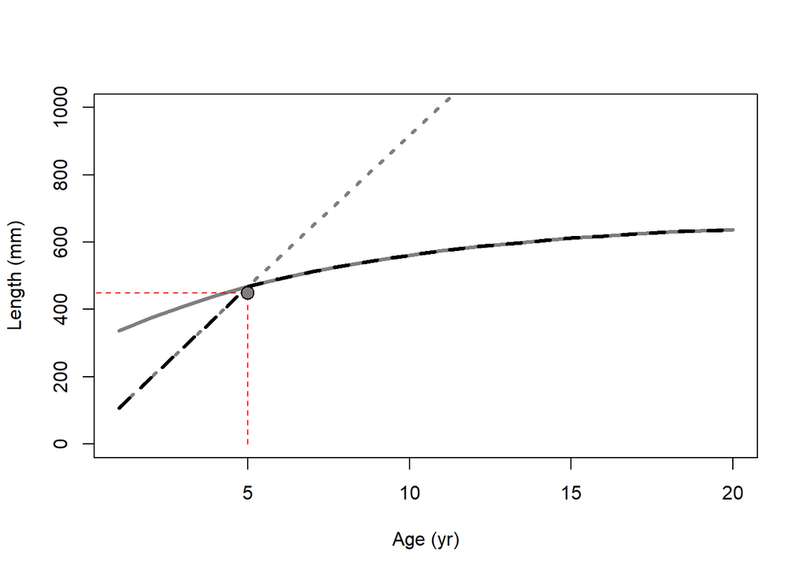

```r
linf <- 3 * h/g  # conversion for the VBGF L-infinity
vbk <- log(1 + g/3)  # conversion for the VBGF parameter kappa
t0 <- Tmat + log(1 - g * (Tmat - t1)/3)/log(1 + g/3)  #conversion for the VBGF parameter t0
true.par <- list(h = h, T.mat = Tmat, t1 = t1, g = g, lengthCV = cv)  # save 'true' parameters to a list


lena_phase1 <- h * (ages - t1)  # length-at-age for phase 1
lena_phase2 <- linf * (1 - exp(-vbk * (ages - t0)))  # length-at-age for phase 2
biphasic <- ifelse(ages <= Tmat, lena_phase1, lena_phase2)  #if-else statement for which phase a fish is allocating surplus energy

plot(ages, lena_phase1, ylab = "Length (mm)", xlab = "Age (yr)", lty = 3, type = "l",
    col = "grey50", lwd = 3, ylim = c(0, 1000))
lines(ages, lena_phase2, col = "grey50", lwd = 3)
lines(ages, biphasic, lty = 2, lwd = 3)
segments(x0 = Tmat, x1 = Tmat, y0 = 0, y1 = h * Tmat + t1, col = "red", lty = 2)  #plot where maturity occurs
segments(x0 = 0, x1 = Tmat, y0 = h * Tmat + t1, y1 = h * Tmat + t1, col = "red",
    lty = 2)  #plot where maturity occurs
points(Tmat, h * Tmat + t1, pch = 21, bg = "grey50", cex = 1.5)
```

We then simulate the data using `rnorm()` and the coefficient of variation in length-at-age specified above.

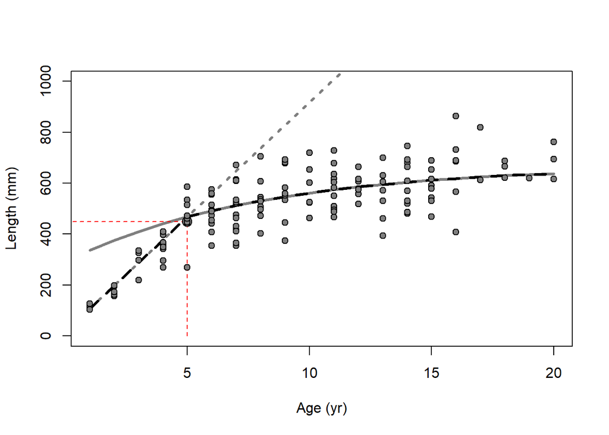

```r
data <- NULL
for (j in 1:max(ages)) {
    lengths <- rnorm(N[j], biphasic[j], biphasic[j] * cv)  # simulate noisy length-at-age data for each age-class
    length_age <- cbind(rep(j, N[j]), lengths)
    data <- rbind(data, length_age)
}
colnames(data) <- c("Age", "Length")  # rename columns in data
data <- as.data.frame(data)  # convert to data frame

plot(ages, lena_phase1, ylab = "Length (mm)", xlab = "Age (yr)", lty = 3, type = "l",
    col = "grey50", lwd = 3, ylim = c(0, 1000))
lines(ages, lena_phase2, col = "grey50", lwd = 3)
lines(ages, biphasic, lty = 2, lwd = 3)
segments(x0 = Tmat, x1 = Tmat, y0 = 0, y1 = h * Tmat + t1, col = "red", lty = 2)  #plot where maturity occurs
segments(x0 = 0, x1 = Tmat, y0 = h * Tmat + t1, y1 = h * Tmat + t1, col = "red",
    lty = 2)  #plot where maturity occurs
points(Tmat, h * Tmat + t1, pch = 21, bg = "grey50", cex = 1.5)
points(data$Age, data$Length, pch = 21, bg = "grey50")  # plot the simulated data
```

### Bayesian estimation

The following model code is in the JAGS language (Plummer 2017). The model loops through each data point and determines the contribution of the predicted length for each fish to the posterior, which is the sum of the log-likelihood and the log-prior. The predicted growth follows the analytical model from the equations in Lester, Shuter & Abrams (2004). There is an if-else statement that determines if the predicted length-at-age of data point *i* comes from the juvenile phase or the adult phase. Modifications to this code require JAGS syntax and not R syntax.

```r
model <- "model {

## likelihood

#loop through all data points
for(i in 1:Nfish) {
length[i] ~ dnorm(pred[i],1/(pred[i]*length.cv)^2)T(0,) # observed length-at-age should be normally distributed around predictions

juv[i] <- h*(age[i]-t1) # predicted growth for fish i for the juvenile phase

adult[i] <- (3*h/g)*(1-exp(-(log(1+g/3))*(age[i]-(T.mat+log(1-g*(T.mat-t1)/3)/log(1+g/3))))) # predicted growth for fish [i] for the adult phase

pred[i] <- ifelse(age[i]<=T.mat,juv[i],adult[i]) # does the age of fish i exceed the maturity predicted for its population?

} # end the calculation of the likelihood



## prior distributions

T.mat ~ dunif(0,max(age))
h ~ dnorm(30,1e-3)T(0,)
t1 ~ dnorm(0,1)
g ~ dnorm(0.1,0.001)T(0,3/(T.mat-t1))
length.cv ~ dgamma(0.01,0.01)
}"
```

We then compile the data into a list for JAGS. In addition, we provide starting values for each parameter within each chain. In this case, we use a random number generator to ‘jitter’ the starting values for each chain. We then compile the starting values for each chain into a list (in effect, creating a ‘list of lists’).

```r
# compile data into a list for JAGS
JAGSdata <- list(Nfish = length(data$Age), age = data$Age, length = data$Length)


inits1 <- list(h = h, T.mat = Tmat, g = g, t1 = t1, length.cv = cv, .RNG.name = "base::Wichmann-Hill",
    .RNG.seed = 735)

# initial estimates of each parameter can be provided. If not provided, JAGS
# will automatically sample a random number from the prior distribution. RNG
# is a random number generator for each chain

inits2 <- inits3 <- inits4 <- inits1

inits2 <- rngList(inits2, inits1)  # jitter chain 2, based on values of chain 1
inits3 <- rngList(inits3, inits1)  # jitter chain 3, based on values of chain 1
inits4 <- rngList(inits4, inits1)  # jitter chain 4, based on values of chain 1

inits <- list(inits1, inits2, inits3, inits4)  # compile all initial values into one list
```

Our last step before fitting the model is to provide some parameters for the JAGS MCMC algorithm. We first create the stochastic nodes to be monitored. We then store values for the thinning rate, the length of the burn-in (or warmup) period, and the length of the adaptation period. In this case, we specify these values based on the total number of posterior draws desired for each chain.

```r
mon_names <- c(names(inits3)[-c(length(inits3), length(inits3) - 1)])  # create the stochastic nodes to be monitored

Nsamp <- 1000  # how many posterior samples does each chain need to get, after thinning and burin-in and adaptation?
thin_rt <- 20  # thinning rate
burnins <- 0.75 * round(Nsamp * thin_rt, 0)  # length of burn-in, based on the number of total posterior draws
adaptin <- round(0.4 * burnins, 0)  # length of adaptation
```

We use the `run.jags()` command (Denwood 2016) to fit the model, and we reference the JAGS parameters as specified above. We use the `rjags` method in this case – for larger datasets or more complicated (e.g., hierarchical) models, the `rjparallel` method may be preferred. We also calculate the computation time using `proc.time()`. Finally, we call the summary of the model fit. Note that results will vary slightly due to MCMC error.

```r
a <- proc.time()
results <- run.jags(model = model, monitor = mon_names, data = JAGSdata, n.chains = 4,
    method = "rjags", inits = inits, plots = F, silent.jag = F, modules = c("bugs",
        "glm", "dic"), sample = Nsamp, adapt = adaptin, burnin = burnins, thin = thin_rt,
    summarise = F)
## Compiling rjags model...
## Calling the simulation using the rjags method...
## Adapting the model for 6000 iterations...
## Burning in the model for 15000 iterations...
## Running the model for 20000 iterations...
## Simulation complete
## Finished running the simulation
b <- (proc.time() - a)
print(b[3]/60)  # computation time in minutes
```

```
##  elapsed
## 5.811167
```

```r
sum_results <- summary(results)
## Calculating summary statistics...
## Calculating the Gelman-Rubin statistic for 5 variables....
sum_results
```

```
##              Lower95     Median     Upper95       Mean          SD
## h         74.5368925 83.3907521 93.45504763 83.4705159 4.840539497
## T.mat      4.5778836  5.3238274  6.20812580  5.3460794 0.407222078
## g          0.3107802  0.3636590  0.42127477  0.3644178 0.028648139
## t1        -0.6433049 -0.3166678 -0.02707536 -0.3282846 0.160887806
## length.cv  0.1395196  0.1565569  0.17694311  0.1571515 0.009624856
##                 Mode        MCerr MC%ofSD SSeff       AC.200      psrf
## h         83.3145902 0.1260523048     2.6  1475  0.007037056 0.9998464
## T.mat      5.2670530 0.0087351381     2.1  2173 -0.018060395 1.0001232
## g          0.3651369 0.0007141561     2.5  1609  0.022527333 1.0000020
## t1        -0.2947673 0.0037569623     2.3  1834  0.012459881 0.9999467
## length.cv  0.1556770 0.0001521570     1.6  4001  0.005564328 0.9996979
```

### Saving and visualizing results

We will now use `plot(results)` to show some diagnostic plots that evaluate whether the posterior has converged on a stable mode using the package `coda()` (Plummer *et al.* 2006).

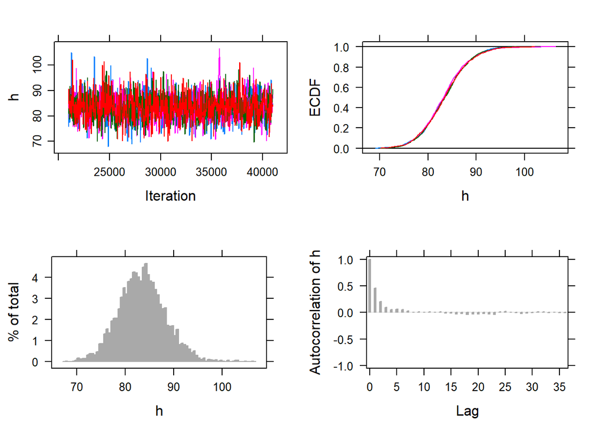

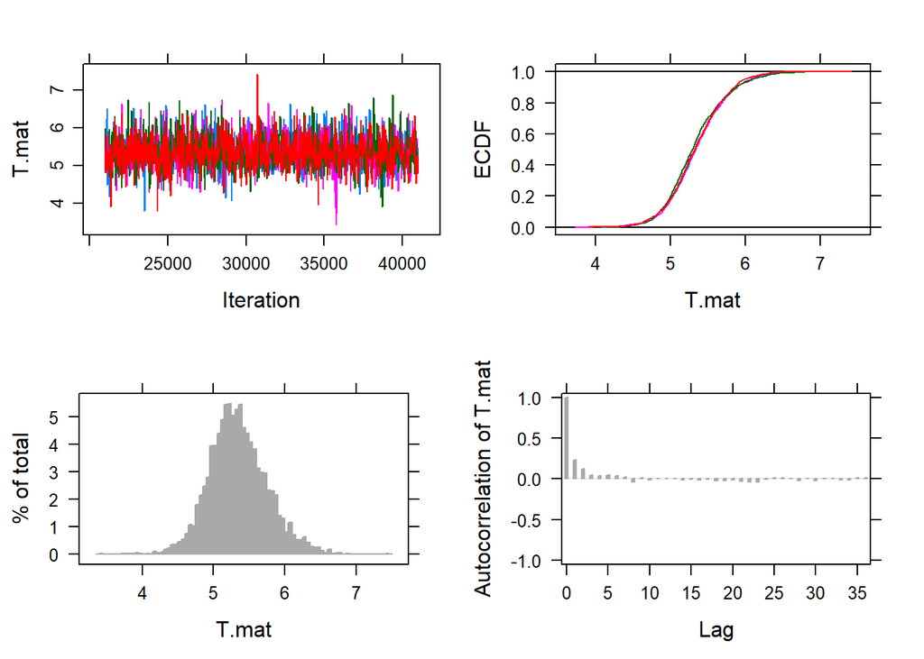

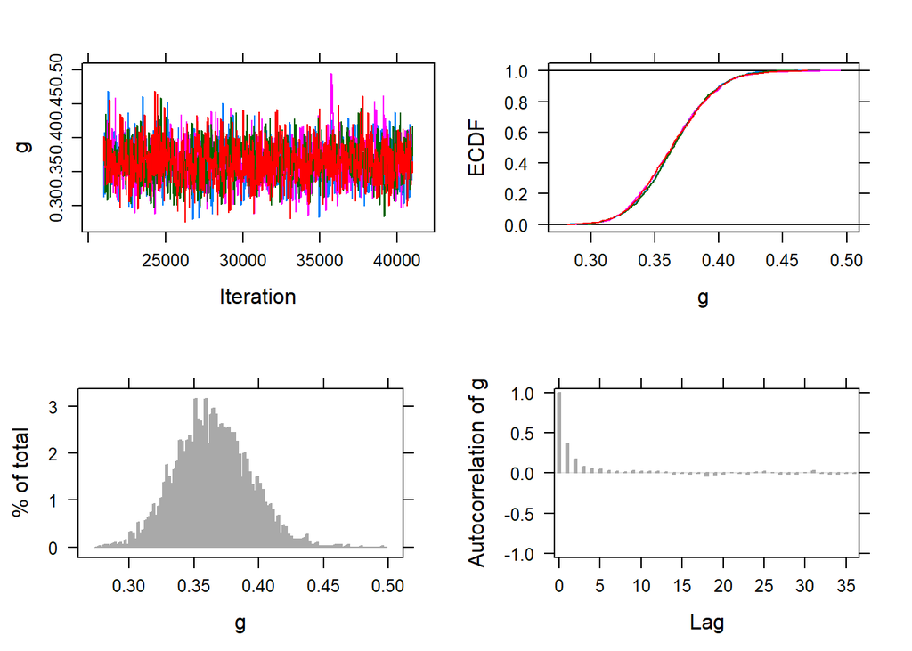

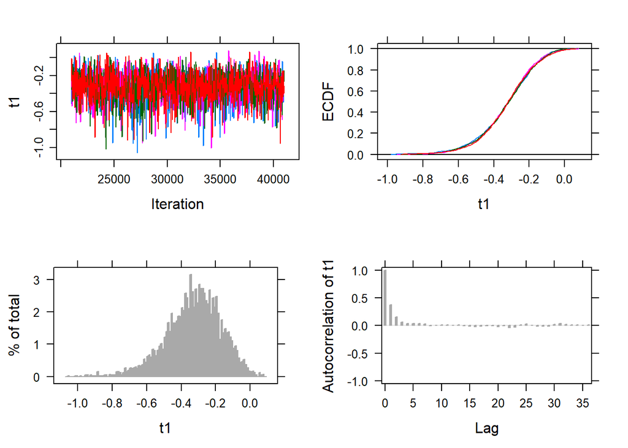

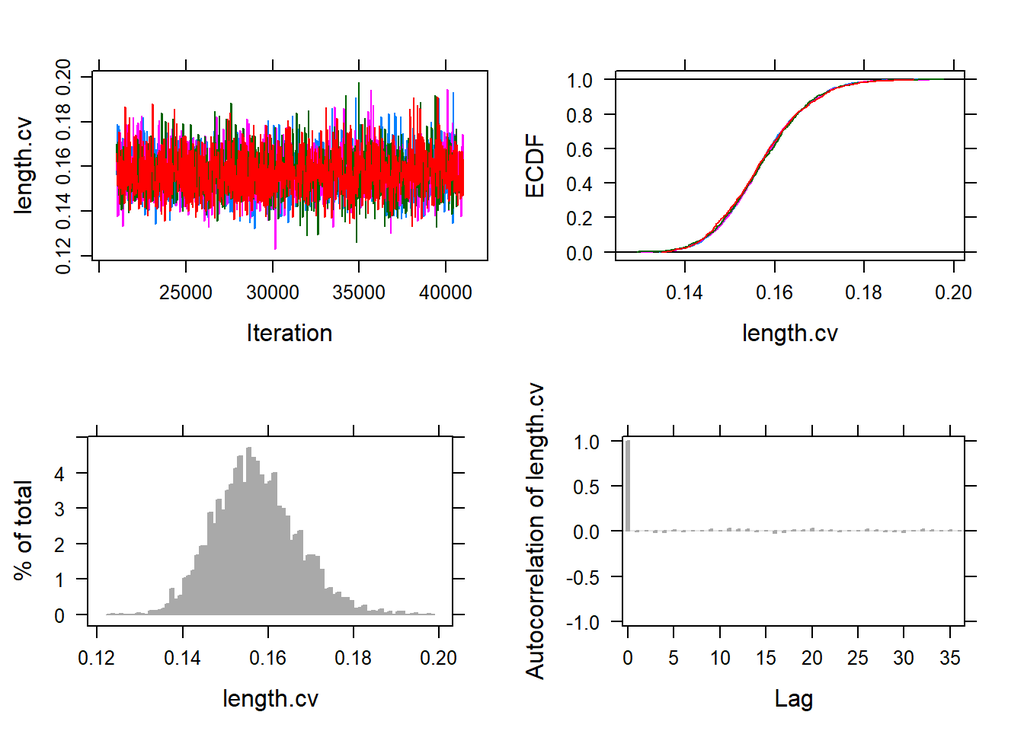

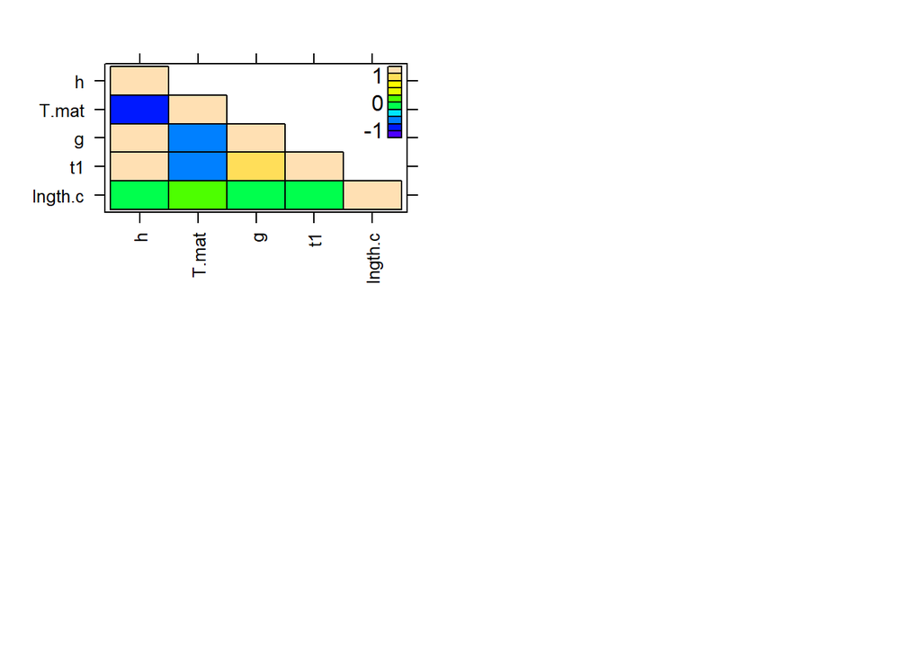

```r
plot(results)
## Generating summary statistics and plots (these will NOT be saved
## for reuse)...
## Calculating summary statistics...
## Calculating the Gelman-Rubin statistic for 5 variables....
```

We then show a percent bias plot. Our results suggest that parameters for this one randomized dataset were estimated well, apart from the parameter $t_1$, which was estimated with noise. We could repeat this trial many times to get a general idea of how well the model recovers true life history parameters of interest (we do this in Appendix I).

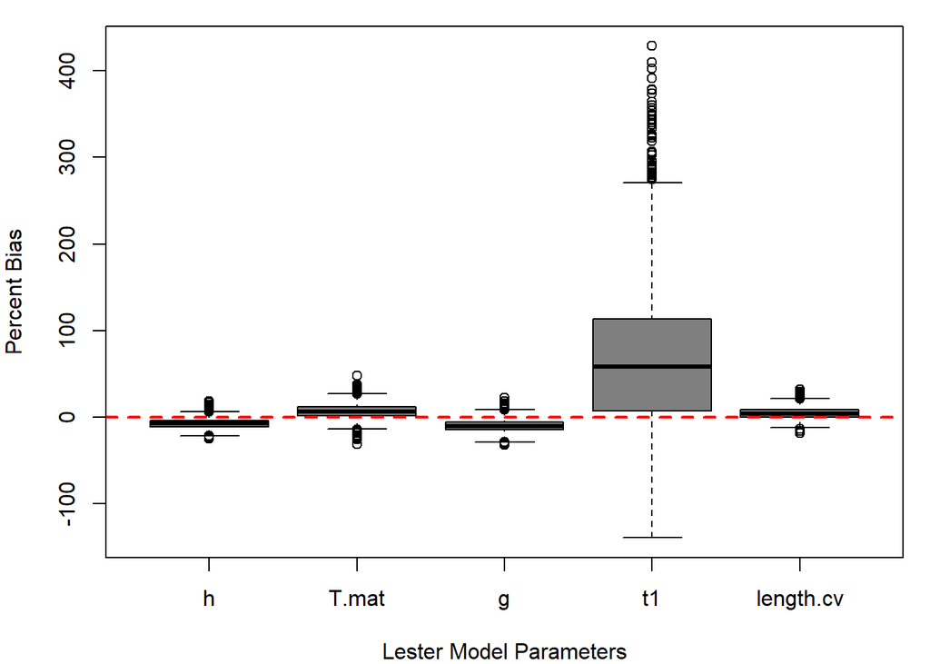

```r
par(mfrow = c(1, 1))
par(mar = c(4, 4, 1, 1))
TheRes <- as.matrix(as.mcmc.list(results), chain = F)
# TheRes <- read.table(ResultsFile,header=TRUE) # read into
true.par <- as.vector(c(h, Tmat, g, t1, cv))
dat <- t(apply(TheRes, 1, FUN = function(x) {
    (x - true.par)/true.par * 100
}))
boxplot(dat, ylab = "Percent Bias", xlab = "Lester Model Parameters", col = "grey50")
abline(h = 0, lty = 2, col = "red", lwd = 2)
```

Next, we will generate a ‘pairs plot’ to see how correlated the parameters are during the MCMC estimation. One may wish to use a multivariate normal distribution in the JAGS model above to allow for the correlations to be incorporated into the MCMC sampling (Helser & Lai 2004).

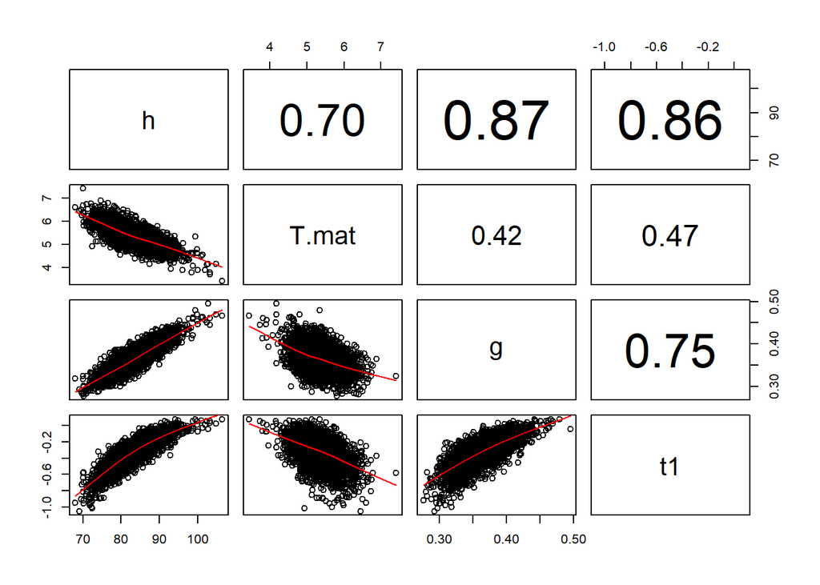

```r
pairs(TheRes[, -5], lower.panel = panel.smooth, upper.panel = panel.cor)
```

### Posterior predictive check

Next, we conduct a posterior predictive check (Gelman *et al.* (2013)). We simulate replicated data from our fitted JAGS model (with associated uncertainty for each estimated parameter from the model) and compare the distribution of our new *simulated* data to the *observed* data. In this case, the *observed* data is our original simulated data used in the model fitting in the `data` object.

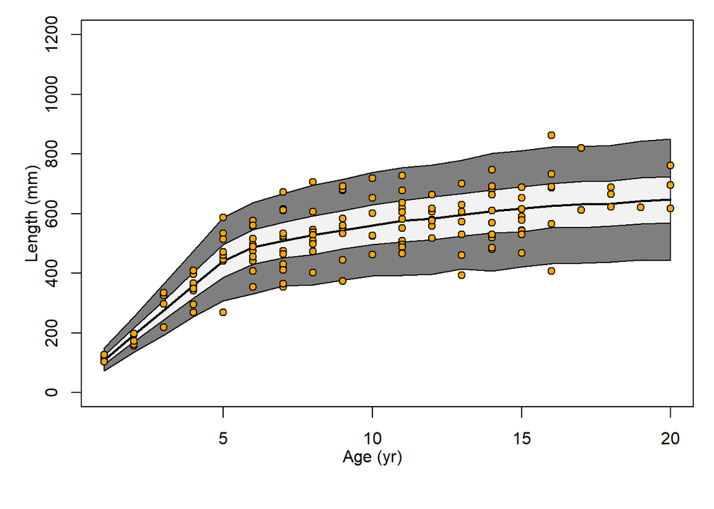

```r
age_vec <- c(ages, rev(ages))
post_pred <- matrix(NA, nrow = nrow(TheRes), ncol = length(ages))
# Above code creates an empty array to track length-at-age for posterior
# draw j
par(mfrow = c(1, 1))
par(mar = c(5, 4, 1, 1))
layout(matrix(1, nrow = 1, ncol = 1))
for (j in 1:nrow(TheRes)) {
    h_j <- TheRes[j, match("h", colnames(TheRes))]
    g_j <- TheRes[j, match("g", colnames(TheRes))]
    Tm_j <- TheRes[j, match("T.mat", colnames(TheRes))]
    t1_j <- TheRes[j, match("t1", colnames(TheRes))]
    cv_j <- TheRes[j, match("length.cv", colnames(TheRes))]

    linf <- 3 * h_j/g_j  # conversion for the VBGF L-infinity
    vbk <- log(1 + g_j/3)  # conversion for the VBGF parameter kappa
    t0 <- Tm_j + log(1 - g_j * (Tm_j - t1_j)/3)/log(1 + g_j/3)  #conversion for the VBGF parameter t0


    juv_j <- h_j * (ages - t1_j)
    adult_j <- linf * (1 - exp(-vbk * (ages - t0)))
    pred_j <- ifelse(ages < Tm_j, juv_j, adult_j)
    pred_j[pred_j < 0] <- 0.001
    post_pred[j, ] <- abs(rnorm(length(ages), pred_j, pred_j * cv_j))
}
quants <- t(apply(post_pred[, ], 2, FUN = quantile, probs = c(0.025, 0.225,
    0.5, 0.775, 0.975), na.rm = TRUE))
plot(age_vec, c(quants[, 1], rev(quants[, 5])), type = "l", lwd = 2, col = NA,
    ylab = "", xlab = "", ylim = c(0, 1200))
axis(1, at = median(c(0, max(ages))), "Age (yr)", tick = FALSE, line = 0.9)
axis(2, at = 600, "Length (mm)", tick = FALSE, line = 1)
polygon(age_vec, c(quants[, 1], rev(quants[, 5])), col = "grey50")
polygon(age_vec, c(quants[, 2], rev(quants[, 4])), col = "grey95")
lines(ages, quants[, 3], lwd = 2, col = "black")
points(data$Age, data$Length, pch = 21, bg = "orange")
```

The posterior predictive distribution covers most of the data, and we can see from graphical portrayal that there are no systematic discrepancies between the *observed* and *simulated* data. In general, we might conclude the model is valid and fits well to the data (one could conduct alternative Bayesian goodness-of-fit tests as well).

## References

Denwood, M.J. (2016). runjags: An R package providing interface utilities, model templates, parallel computing methods and additional distributions for MCMC models in JAGS. *Journal of Statistical Software*, **71**, 1–25.

Gelman, A., Carlin, J., Stern, H., Dunson, D., Vehtari, A. & Rubin, D. (2013). *Bayesian Data Analysis*, 3rd edn. Chapman and Hall/CRC Press.

Helser, T.E. & Lai, H.-L. (2004). A bayesian hierarchical meta-analysis of fish growth: With an example for north american largemouth bass, micropterus salmoides. *Ecological Modelling*, **178**, 399–416.

Lester, N.P., Shuter, B.J. & Abrams, P.A. (2004). Interpreting the von bertalanffy model of somatic growth in fishes: The cost of reproduction. *Proceedings of the Royal Society B: Biological Sciences*, **271**, 1625–1631.

Lorenzen, K. (2016). Toward a new paradigm for growth modeling in fisheries stock assessments: Embracing plasticity and its consequences. *Fisheries Research*, **180**, 4–22.

Plummer, M. (2017). JAGS: A program for analysis of bayesian graphical models using gibbs sampling.

Plummer, M., Best, N., Cowles, K. & Vines, K. (2006). CODA: Convergence diagnosis and output analysis for mcmc. *R News*, **6**, 7–11.

Wilson, K.L., Honsey, A., Moe, B. & Venturelli, P. (2017). Growing the biphasic framework: techniques and recommendations for fitting emerging growth models. *Methods in Ecology and Evolution*, **In Review**.